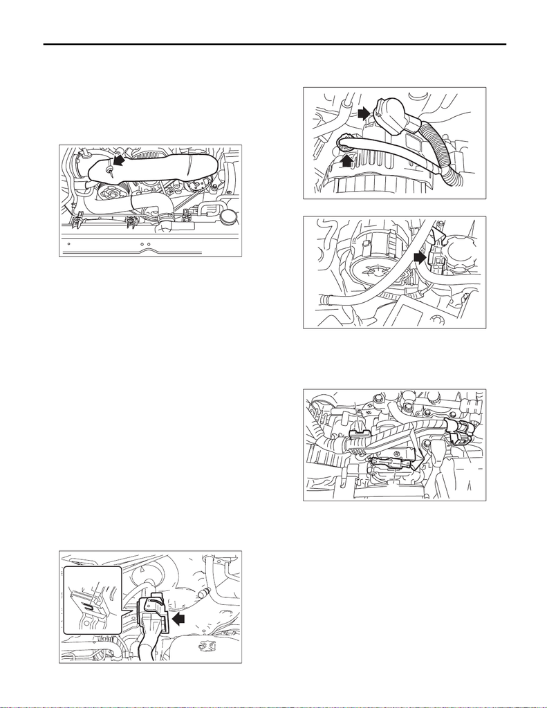

ME(STI)-30

Engine Assembly

MECHANICAL

9. Engine Assembly

A: REMOVAL

1) Remove the striker - front hood. <Ref. to EB-11,

DISASSEMBLY, Front Hood.>

2) Fully open the front hood. <Ref. to NT-20,

FRONT HOOD DAMPER STAY, NOTE, Note.>

3) Remove the V-belt covers.

4) Collect the refrigerant from A/C system. <Ref. to

AC-26, Refrigerant Recovery Procedure.>

5) Release the fuel pressure. <Ref. to FU(STI)-64,

RELEASING OF FUEL PRESSURE, PROCE-

DURE, Fuel.>

6) Remove the battery. <Ref. to SC(STI)-21, RE-

MOVAL, Battery.>

7) Open the fuel filler lid and remove the fuel filler

cap.

NOTE:

This operation is required to release the inner pres-

sure of the fuel tank.

8) Remove the air intake duct and air cleaner case

(rear). <Ref. to IN(STI)-11, REMOVAL, Air Intake

Duct.> <Ref. to IN(STI)-9, REMOVAL, Air Cleaner

Case.>

9) Remove the intercooler. <Ref. to IN(STI)-13,

REMOVAL, Intercooler.>

10) Remove the radiator. <Ref. to CO(STI)-19, RE-

MOVAL, Radiator.>

11) Remove the coolant filler tank. <Ref. to

CO(STI)-28, REMOVAL, Coolant Filler Tank.>

12) Disconnect the bulkhead harness connectors

from the engine harness connectors.

13) Lift the claw (A) and remove the engine har-

ness connector from the engine harness bracket.

14) Disconnect the following connectors and termi-

nals.

(1) Generator connector and terminal

(2) Secondary air pump connector

15) Disconnect connector (A) from the A/C com-

pressor.

16) Remove the clip (B) securing the generator

cord, and move the generator cord to the left side

wheel apron.

FU-03487

FU-08327

(A)

ME-04187

ME-04655

ME-04681

(B)

(A)

(B)

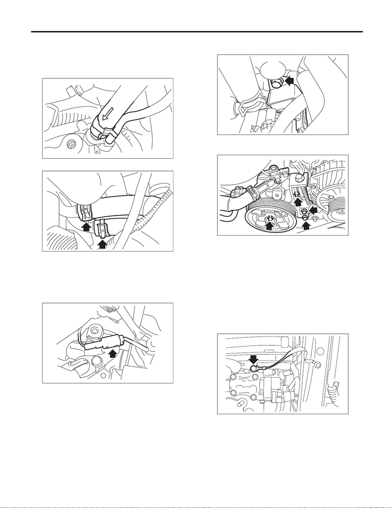

ME(STI)-31

Engine Assembly

MECHANICAL

17) Disconnect the following hoses.

(1) A/C pressure hose <Ref. to AC-63, RE-

MOVAL, Hose and Pipe.>

(2) Brake booster vacuum hose (A) and pres-

sure regulator vacuum hose (B)

(3) Heater inlet hose and heater outlet hose

18) Remove the power steering pump.

(1) Remove the front side belt. <Ref. to

ME(STI)-41, FRONT SIDE BELT, REMOVAL,

V-belt.>

(2) Disconnect the connector from power steer-

ing pump switch.

(3) Remove the bolt which holds purge control

solenoid valve 1 onto intake manifold.

(4) Remove the power steering pump from the

engine.

(5) Place the power steering pump on the right

side wheel apron.

19) Remove the center exhaust pipe. <Ref. to

EX(STI)-7, REMOVAL, Center Exhaust Pipe.>

20) Remove the turbocharger. <Ref. to IN(STI)-16,

REMOVAL, Turbocharger.>

21) Remove the joint pipe and front exhaust pipe.

<Ref. to EX(STI)-11, REMOVAL, Joint Pipe.>

<Ref. to EX(STI)-5, REMOVAL, Front Exhaust

Pipe.>

22) Disconnect the ground cable on the engine

side.

ME-05007

E N G

(A)

(B)

ME-04190

FU-04598

EC-03005

ME-07934

ME-07887

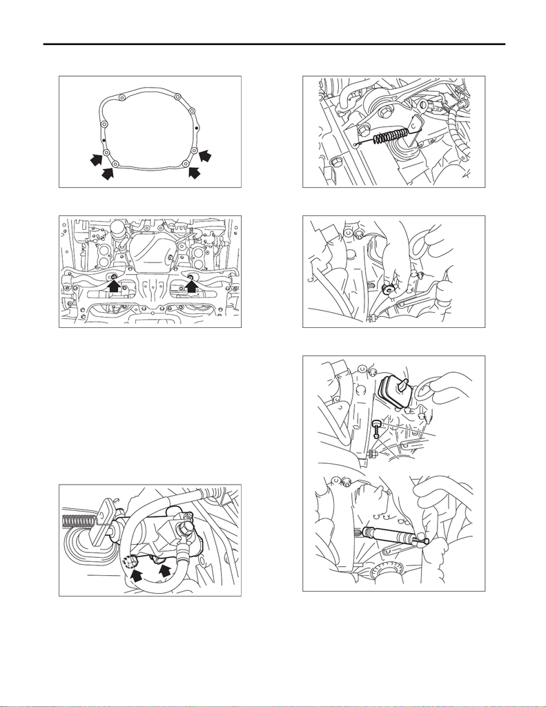

ME(STI)-32

Engine Assembly

MECHANICAL

23) Remove the bolts and nuts which hold the low-

er side of transmission to the engine.

24) Remove the nuts which secure the engine

mounting to the front crossmember.

25) Lower the vehicle.

26) Remove the starter. <Ref. to SC(STI)-7, RE-

MOVAL, Starter.>

27) Separate the clutch release fork from the re-

lease bearing.

NOTE:

This procedure is required to remove engine with

the release bearing assembled to the clutch cover.

(1) Remove the operating cylinder from the

transmission.

NOTE:

Move the removed operating cylinders to a location

that does not interfere operation.

(2) Remove the return spring from the release

fork.

(3) Remove the service hole plug using a hexa-

gon wrench.

(4) Attach a 6-mm bolt to the release shaft, and

pull out the release shaft.

MT-00077

LU-03187

CL-00445

(A) Release fork shaft

(B) Bolt

MT-02302

ME-00042

ME-00043

(B)

(A)

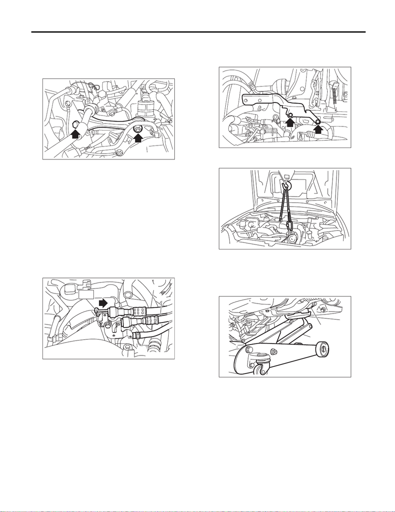

ME(STI)-33

Engine Assembly

MECHANICAL

(5) Lift the release fork, and remove from the

tab of the release bearing. Pull the release fork

to the engine side, and make it so that it moves

freely.

28) Remove the pitching stopper.

29) Disconnect the fuel delivery hose, fuel return

hose and evaporation hose.

CAUTION:

• Be careful not to spill fuel.

• Catch the fuel from hoses using a container

or cloth.

(1) Set the ST to the fuel pipe.

ST 42099AE000 QUICK CONNECTOR RE-

LEASE

(2) Disconnect the quick connector of the fuel

delivery hose and fuel return hose by pushing

the ST in the direction of the arrow.

(3) Remove the clip and disconnect the evapo-

ration hose from the fuel pipe.

30) Install the intercooler stay RH No. 2.

Tightening torque:

16 N·m (1.6 kgf-m, 11.8 ft-lb)

31) Support the engine with a lifting device and

wire ropes.

32) Support the transmission with a garage jack.

CAUTION:

Be sure to perform this procedure to prevent

the transmission from lowering by its own

weight.

(A) Fuel delivery hose

(B) Fuel return hose

(C) Evaporation hose

ME-07890

ME-05008

(A)

(B)

ST

(C)

(A) Transmission

(B) Garage jack

ME-07888

LU-00222

ME-04959

(B)

(A)

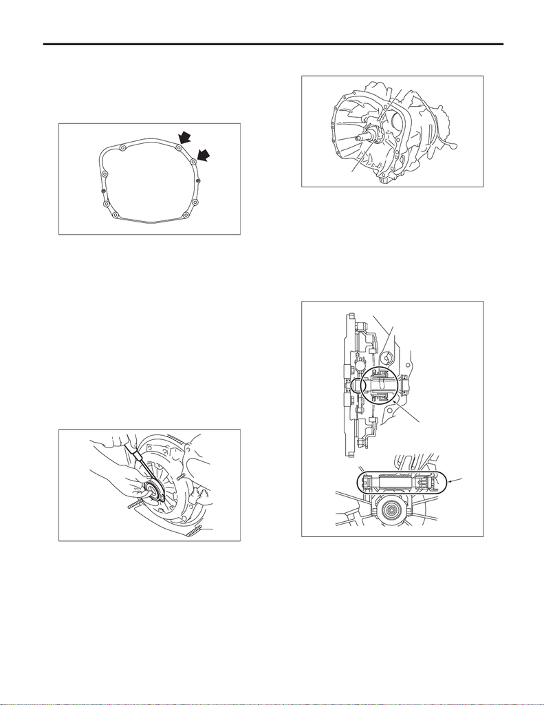

ME(STI)-34

Engine Assembly

MECHANICAL

33) Remove the bolts which hold the upper side of

the transmission to the engine.

CAUTION:

Before removing the engine away from trans-

mission, check to be sure no work has been

overlooked.

34) Remove the engine from the vehicle.

NOTE:

Be careful not to damage adjacent parts or body

panels with crank pulley, oil level gauge, etc.

(1) Slightly raise the engine.

(2) Raise the transmission with garage jack.

(3) Move the engine horizontally until main

shaft is withdrawn from clutch cover.

(4) Slowly move the engine away from engine

compartment.

35) Remove the engine mounting from the engine.

B: INSTALLATION

1) Install the clutch release fork and bearing to the

transmission.

(1) Using a flat tip screwdriver, remove the re-

lease bearing from the clutch cover.

(2) Attach the release bearing to the transmis-

sion.

(3) Install the release fork into the release bear-

ing tab.

(4) Apply grease to the specified areas.

Grease:

Spline part

NICHIMOLY N-130 or equivalent

Shaft part

KOPR-KOTE or equivalent

MT-01524

ME-00051

(A) Release fork

(B) Release bearing

(A) Spline

(B) Shaft

ME-02591

(A)

(B)

CL-00304

(A)

(B)

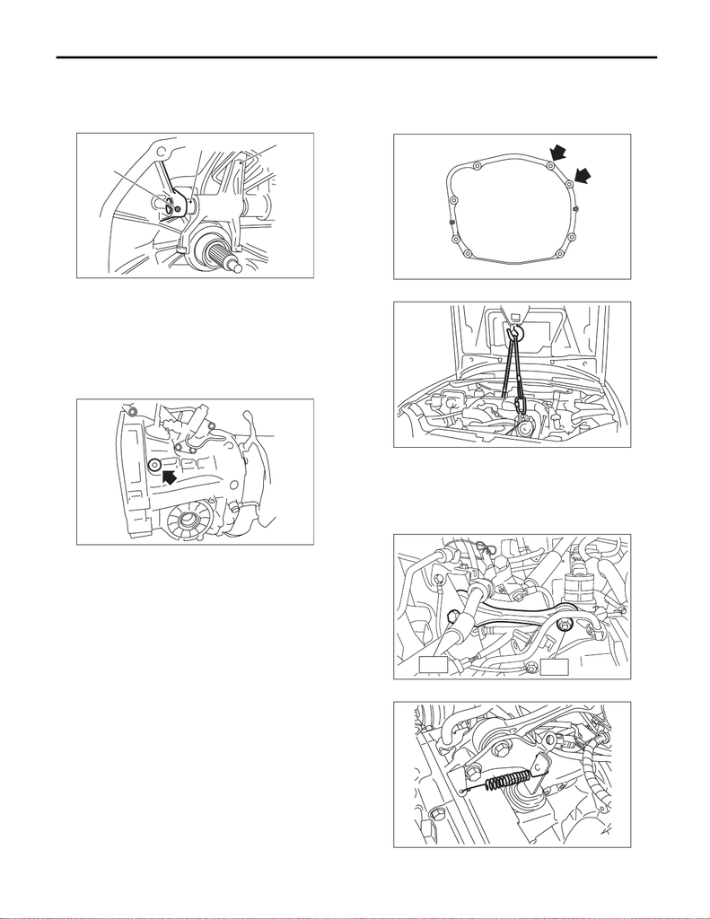

ME(STI)-35

Engine Assembly

MECHANICAL

(5) Insert the release shaft to release fork.

NOTE:

Allow the cutout portion of release shaft to come

into contact with the spring pin.

(6) Install the service hole plug.

Tightening torque:

44 N·m (4.5 kgf-m, 32.5 ft-lb)

2) Install the engine mounting onto the engine.

Tightening torque:

35 N·m (3.6 kgf-m, 25.8 ft-lb)

3) Apply a small amount of grease to splines of

main shaft.

Grease:

NICHIMOLY N-130 or equivalent

4) Position the engine in engine compartment and

align it with transmission.

NOTE:

Be careful not to damage adjacent parts or body

panels with crank pulley, oil level gauge, etc.

5) Install the bolts which hold upper side of trans-

mission to engine.

Tightening torque:

50 N·m (5.1 kgf-m, 36.9 ft-lb)

6) Remove the lifting device and wire ropes.

7) Remove the garage jack.

8) Install the pitching stopper.

Tightening torque:

T1: 50 N·m (5.1 kgf-m, 36.9 ft-lb)

T2: 58 N·m (5.9 kgf-m, 42.8 ft-lb)

9) Install the return spring.

(A) Release fork

(B) Release shaft

(C) Spring pin

ME-00054

(A)

(B)

(C)

ME-02592

MT-01524

LU-00222

ME-07891

T2

T1

MT-02302

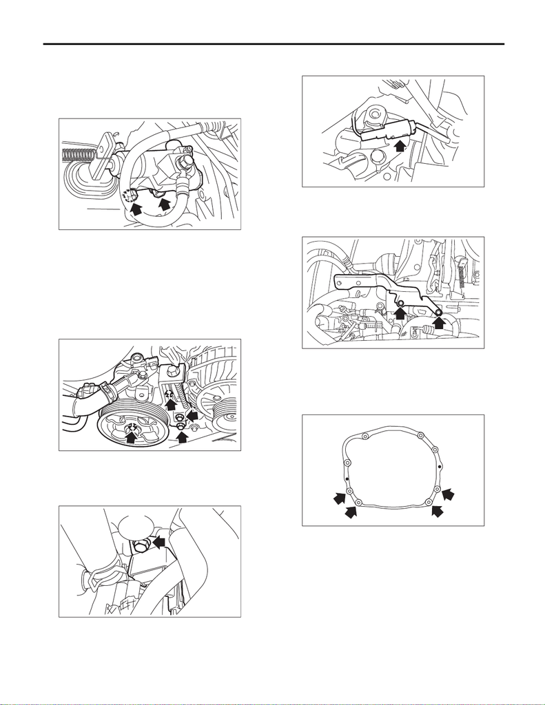

ME(STI)-36

Engine Assembly

MECHANICAL

10) Install the operating cylinder.

NOTE:

Check that the clutch hose is routed properly.

Tightening torque:

41 N·m (4.2 kgf-m, 30.2 ft-lb)

11) Install the starter. <Ref. to SC(STI)-7, INSTAL-

LATION, Starter.>

12) Install the power steering pump.

(1) Install the power steering pump onto the en-

gine.

Tightening torque:

Refer to “COMPONENT” of “Power Steering”

for the tightening torque. <Ref. to PS-4, COM-

PONENT, General Description.>

(2) Install the purge control solenoid valve 1 to

the intake manifold.

Tightening torque:

19 N·m (1.9 kgf-m, 14.0 ft-lb)

(3) Connect the connector to the power steering

pump switch.

(4) Install the front side belt. <Ref. to ME(STI)-

41, FRONT SIDE BELT, INSTALLATION, V-

belt.>

13) Remove the intercooler stay RH No. 2.

14) Lift up the vehicle.

15) Install the bolts and nuts which hold lower side

of the transmission to engine.

Tightening torque:

50 N·m (5.1 kgf-m, 36.9 ft-lb)

CL-00445

ME-07934

EC-03005

FU-04598

ME-07888

MT-00077

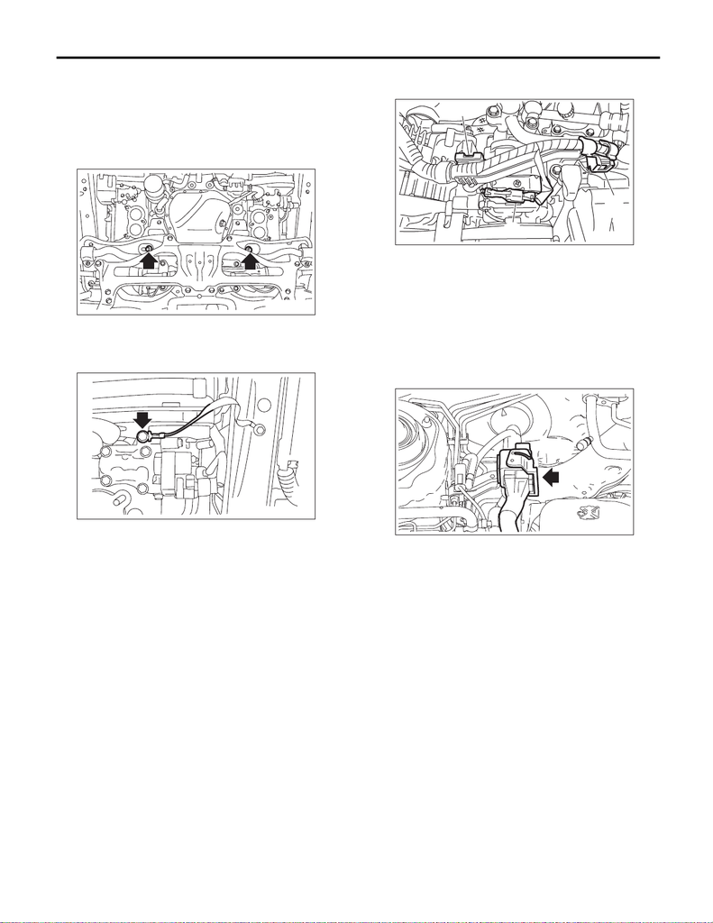

ME(STI)-37

Engine Assembly

MECHANICAL

16) Install the nuts which hold the engine mounting

to the crossmember.

NOTE:

Use a new nut.

Tightening torque:

60 N·m (6.1 kgf-m, 44.3 ft-lb)

17) Connect the ground cable.

Tightening torque:

7.5 N·m (0.8 kgf-m, 5.5 ft-lb)

18) Install the joint pipe and front exhaust pipe.

<Ref. to EX(STI)-5, INSTALLATION, Front Ex-

haust Pipe.> <Ref. to EX(STI)-11, INSTALLATION,

Joint Pipe.>

19) Install the turbocharger. <Ref. to IN(STI)-17,

INSTALLATION, Turbocharger.>

20) Install the center exhaust pipe. <Ref. to

EX(STI)-8, INSTALLATION, Center Exhaust

Pipe.>

21) Connect the following hoses.

(1) Fuel delivery hose, fuel return hose and

evaporation hose

(2) Heater inlet hose and heater outlet hose

(3) Brake booster vacuum hose and pressure

regulator vacuum hose

(4) A/C pressure hose <Ref. to AC-67, INSTAL-

LATION, Hose and Pipe.>

22) Secure the generator cord using the clip (B)

and connect the connector (A) to A/C compressor.

23) Connect the following connectors and termi-

nals.

(1) Generator connector and terminal

Tightening torque:

15 N·m (1.5 kgf-m, 11.1 ft-lb)

(2) Secondary air pump connector

24) Install the engine harness connector to engine

harness bracket, then connect the bulkhead har-

ness connector to the engine harness connector.

25) Install the intercooler. <Ref. to IN(STI)-14, IN-

STALLATION, Intercooler.>

26) Install the radiator. <Ref. to CO(STI)-20, IN-

STALLATION, Radiator.>

27) Install the coolant filler tank. <Ref. to CO(STI)-

28, INSTALLATION, Coolant Filler Tank.>

28) Install the air cleaner case and air intake duct.

<Ref. to IN(STI)-9, INSTALLATION, Air Cleaner

Case.> <Ref. to IN(STI)-11, INSTALLATION, Air

Intake Duct.>

29) Install the battery. <Ref. to SC(STI)-21, IN-

STALLATION, Battery.>

30) Fill engine coolant. <Ref. to CO(STI)-13, FILL-

ING OF ENGINE COOLANT, REPLACEMENT,

Engine Coolant.>

31) Charge the A/C system with refrigerant. <Ref.

to AC-27, PROCEDURE, Refrigerant Charging

Procedure.>

LU-03187

ME-07887

ME-04681

(B)

(A)

(B)

FU-08417

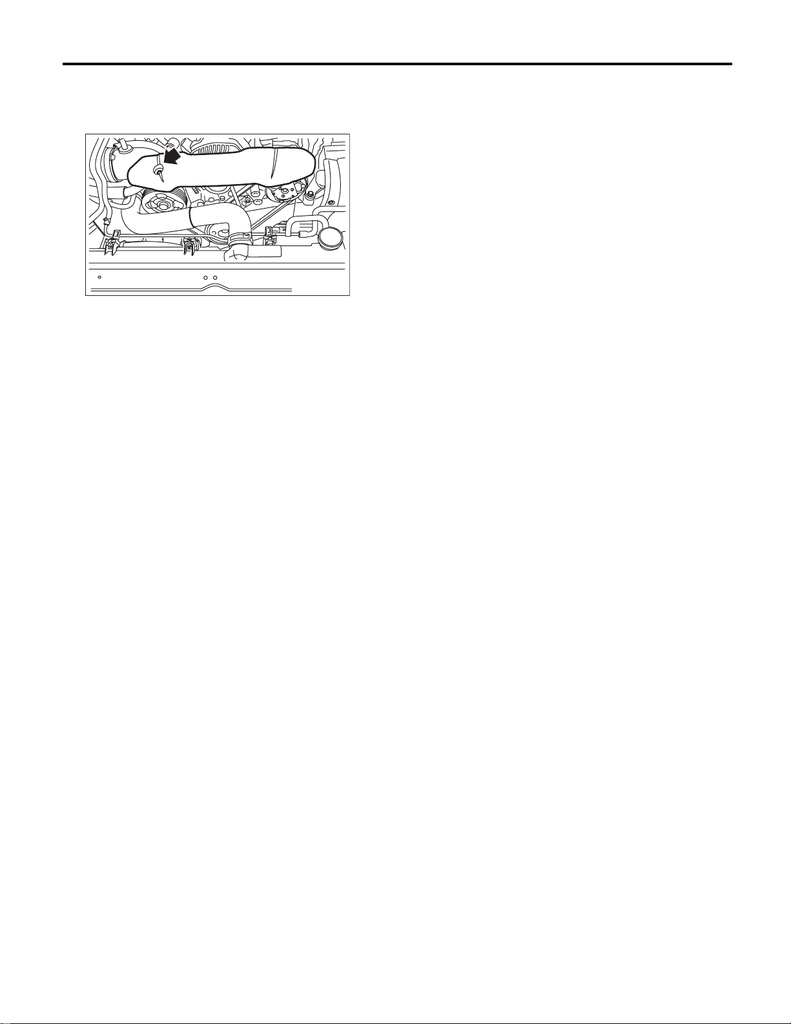

ME(STI)-38

Engine Assembly

MECHANICAL

32) Install the V-belt cover.

Tightening torque:

13 N·m (1.3 kgf-m, 9.6 ft-lb)

33) Set the front hood to the normal position. <Ref.

to NT-20, FRONT HOOD DAMPER STAY, NOTE,

Note.>

34) Install the striker - front hood. <Ref. to EB-15,

ASSEMBLY, Front Hood.>

35) Close the front hood.

C: INSPECTION

1) Check that pipes, hoses, connectors and clamps

are installed firmly.

2) Check the engine coolant is at specified level.

3) Start the engine and check for exhaust gas, en-

gine coolant, leaks of fuel, etc. Also check for noise

and vibrations.

FU-03487